# A3: Incarceration

### Variable Comparison Chart

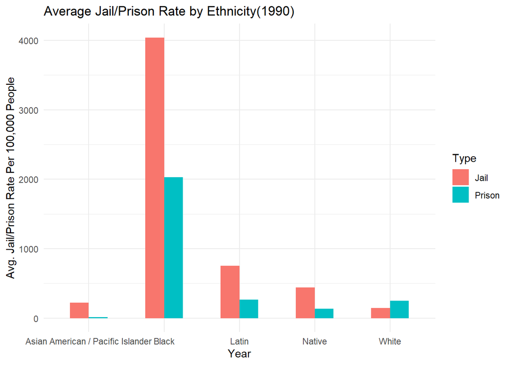

### Map

The following figure shows the Jail Pop Rate of different states in 2018. The red area represents the high Jail Pop Rate, while the black area represents the low Jail Pop Rate. As can be seen from the figure and the map, The Jail Pop Rate is higher in the South than in the North, with louisiana, utah and new mexico having the highest Jail Pop Rate.

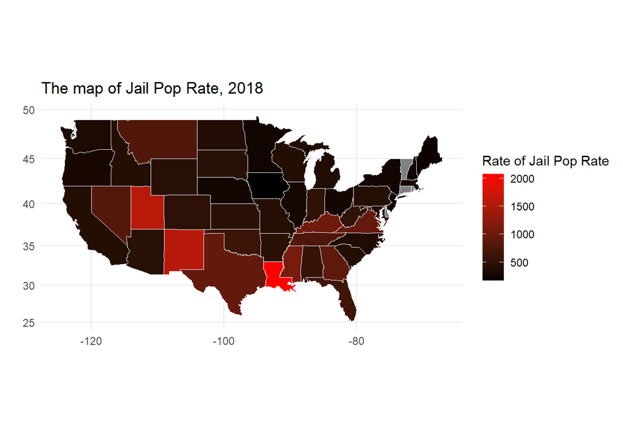